# Mixed-Effects Models

Misc. Hierarchical Examples-Nested

**Review of Fixed vs. Random Effects** (Aho 2014)

**Fixed factor** levels have two characteristics: (1) they are not an obvious subset of a population of factor levels, and (2) the factor levels are informative, and are chosen by the investigator specifically because they have a unique and important meaning. Examples of fixed factor levels include:

- Male and female
- Predator and prey
- Drug A, drug B, and drug C
- Control and treatment
- Before and after
- Tree, grass, shrub, and so on
- Particular variants on a predictor, for example, “high”, “medium”, and “low”

**Random factor** levels have two characteristics: (1) the selected factor levels often can be considered a subset from a population of possible levels, and (2) the factor levels are not informative. Because of these characteristics, we are unlikely to care about particular differences among factor levels. Random factor levels include:

- Time intervals in a time sequence
- A collection of seed types (or some other levels) chosen randomly from a population of seed types (or some other population)
- Nested groups in an observational study
- Subjects on whom repeated measurements are made

If all factors contain fixed factor levels, then one would use a conventional fixed effect model for hypothesis testing procedures. Conversely, if all factors are random, then one should use a random effect model. A design with both random and fixed factors will require a *mixed effect model*. Fixed, random, and mixed effect models are also called model I, model II, and model III ANOVAs, respectively.  
**Examples of different types of hierarchical models** (Schielzeth and Nakagawa 2013, Methods in Ecology and Evolution) https://besjournals.onlinelibrary.wiley.com/doi/10.1111/j.2041-210x.2012.00251.x

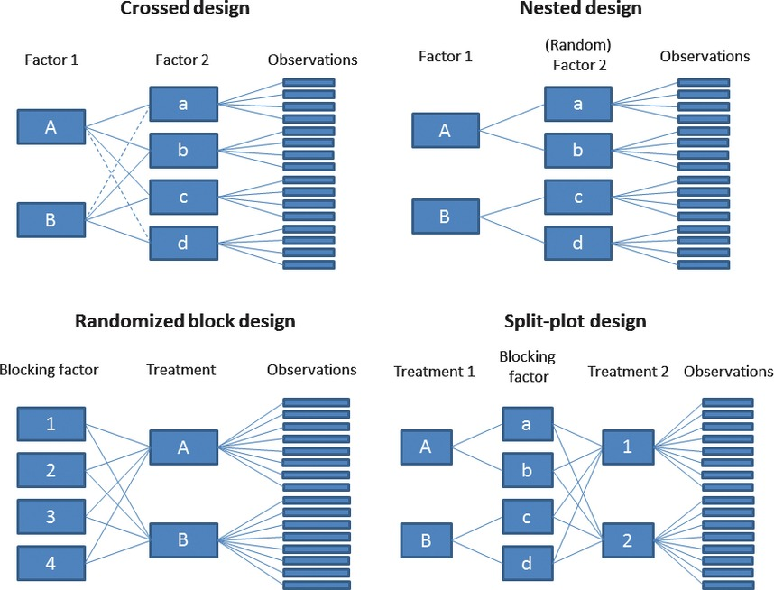

In a **nested design**, each level of the nested predictor is uniquely associated with only one level of the higher-level predictor.

In a **crossed (or factorial) design**, at least one level of each predictor is associated with more than one level of the other predictors. Crossed designs can further be separated into partially or fully crossed.

This basic categorization of the study design does not depend on whether factors are fitted as fixed or random effects.

**Nested Design: Mosquito Wing Length** (Aho 2014, Example 10.13)  
Sokal and Rohlf (2012) measured the variability in wing length (in micrometers) for female mosquitos (*Aedes intrudens*). Four females were randomly selected from each of three cages and two measurements were made on the left wing of each. Both cage and female (in cage) can be seen as random effects. The data are in the dataframe mosquito.

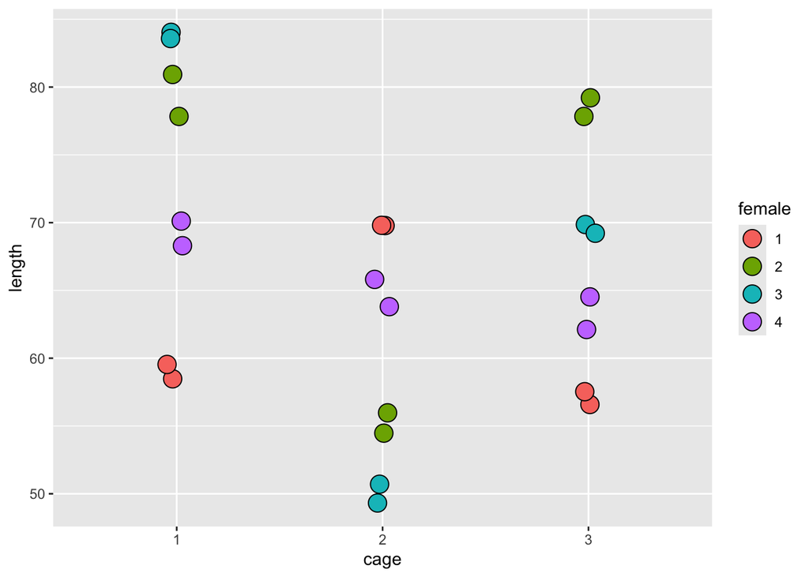

```r
data(mosquito)
ggplot(mosquito, aes(cage, length, colour = female)) +
  geom_jitter(aes(fill=female), colour="black",pch=21, size=5, width = .05)
```

This figure is confusing because of the way the data are coded; all numbers. We actually have 12 females total. We need a graph that makes sense before we can make some models.

```r
#Look at the coding of replicates in the mosquito dataset
mosquito
```

```
##    length cage female measures
## 1    58.5    1      1        1
## 2    59.5    1      1        2
## 3    77.8    1      2        1
## 4    80.9    1      2        2
## 5    84.0    1      3        1
## 6    83.6    1      3        2
## 7    70.1    1      4        1
## 8    68.3    1      4        2
## 9    69.8    2      1        1
## 10   69.8    2      1        2
## 11   56.0    2      2        1
## 12   54.5    2      2        2
## 13   50.7    2      3        1
## 14   49.3    2      3        2
## 15   63.8    2      4        1
## 16   65.8    2      4        2
## 17   56.6    3      1        1
## 18   57.5    3      1        2
## 19   77.8    3      2        1
## 20   79.2    3      2        2
## 21   69.9    3      3        1
## 22   69.2    3      3        2
## 23   62.1    3      4        1
## 24   64.5    3      4        2
```

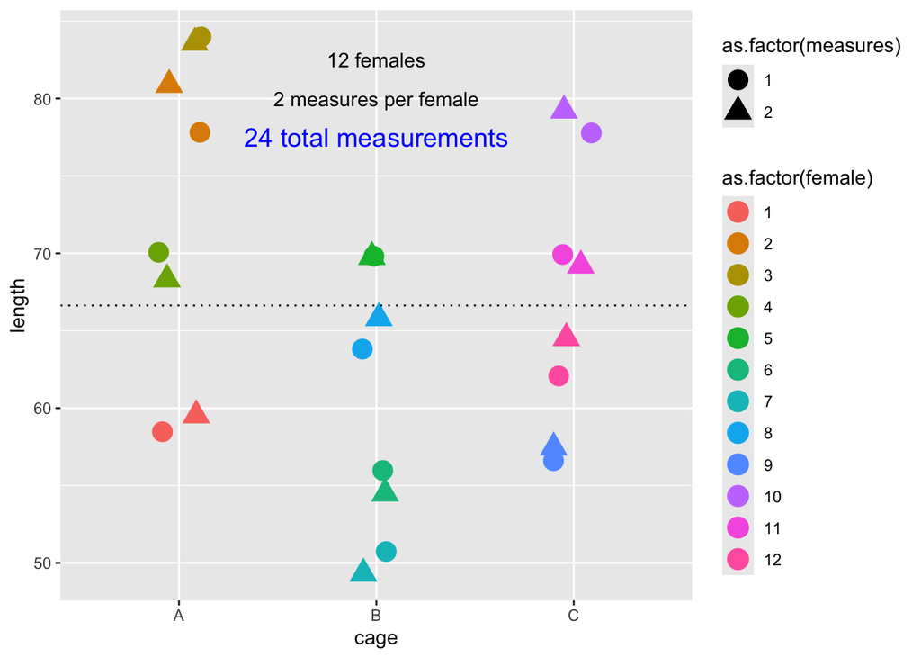

```r
mosquito.recoded <- read.csv("../data/mosquito.recoded.csv")
ggplot(mosquito.recoded, aes(cage, length, colour = as.factor(female), shape=as.factor(measures))) +
  geom_jitter(width =0.15, size=5) +
  annotate("text", x = 2, y = 82.5, label = "12 females") +
  annotate("text", x = 2, y = 80, label = "2 measures per female") +
  annotate("text", x = 2, y = 77.5, label = "24 total measurements", size=5, color="blue") +
  geom_hline(yintercept = 66.63, linetype="dotted")
```

```r
aedes.1 <- lmer(length ~ (1|cage/female), data = mosquito)
anova(aedes.1)
```

```
## Type III Analysis of Variance Table with Satterthwaite's method
##      Sum Sq Mean Sq NumDF DenDF F value Pr(>F)
```

Its not happy, no fixed effects to evaluate, other than intercept of the model, which is the mean of the wing measurements.

```r
summary(aedes.1)
```

```
## Linear mixed model fit by REML. t-tests use Satterthwaite's method [
## lmerModLmerTest]
## Formula: length ~ (1 | cage/female)
##    Data: mosquito
##
## REML criterion at convergence: 130.5
##
## Scaled residuals:
##      Min       1Q   Median       3Q      Max
## -1.29844 -0.58190  0.03584  0.55002  1.41870
##
## Random effects:
##  Groups      Name        Variance Std.Dev.
##  female:cage (Intercept) 94.942   9.744
##  cage        (Intercept) 17.706   4.208
##  Residual                 1.302   1.141
## Number of obs: 24, groups:  female:cage, 12; cage, 3
##
## Fixed effects:
##             Estimate Std. Error     df t value Pr(>|t|)
## (Intercept)   66.633      3.724  2.000   17.89  0.00311 **
## ---
## Signif. codes:  0 '***' 0.001 '**' 0.01 '*' 0.05 '.' 0.1 ' ' 1
```

This model specification makes sense: “Number of obs: 24, groups: female:cage, 12; cage, 3”

Because the design is perfectly balanced, we can obtain the variance component estimates using mean squares from a conventional ANOVA. But this is confusing because df are different than what we might expect (there were only 12 mosquitos in the experiment).

```r
anova(lm(length ~ cage/female, data = mosquito))
```

```
## Analysis of Variance Table
##
## Response: length
##             Df  Sum Sq Mean Sq F value    Pr(>F)
## cage         2  665.68  332.84  255.70 1.452e-10 ***
## cage:female  9 1720.68  191.19  146.88 6.981e-11 ***
## Residuals   12   15.62    1.30
## ---
## Signif. codes:  0 '***' 0.001 '**' 0.01 '*' 0.05 '.' 0.1 ' ' 1
```

But maybe we are actually specifically interested in the differences among cages (cage as fixed effect); or if we had unbalanced sampling.

```r
aedes.2 <- lmer(length ~ cage + (1|cage/female), data = mosquito)
# aedes.wrong <- lmer(length ~ cage + (1|female), data = mosquito)
# this notation assumes every female is in every treatment; they are not
summary(aedes.2)
```

```
## Linear mixed model fit by REML. t-tests use Satterthwaite's method [
## lmerModLmerTest]
## Formula: length ~ cage + (1 | cage/female)
##    Data: mosquito
##
## REML criterion at convergence: 116.3
##
## Scaled residuals:
##      Min       1Q   Median       3Q      Max
## -1.31971 -0.57739  0.05871  0.57288  1.39743
##
## Random effects:
##  Groups      Name        Variance Std.Dev.
##  female:cage (Intercept) 94.942   9.744
##  cage        (Intercept)  2.287   1.512
##  Residual                 1.302   1.141
## Number of obs: 24, groups:  female:cage, 12; cage, 3
##
## Fixed effects:
##             Estimate Std. Error      df t value Pr(>|t|)
## (Intercept)   72.837      5.117  10.732  14.234 2.62e-08 ***
## cage2        -12.875      7.237  10.732  -1.779    0.104
## cage3         -5.737      7.237  10.732  -0.793    0.445
## ---
## Signif. codes:  0 '***' 0.001 '**' 0.01 '*' 0.05 '.' 0.1 ' ' 1
##
## Correlation of Fixed Effects:
##       (Intr) cage2
## cage2 -0.707
## cage3 -0.707  0.500
## optimizer (nloptwrap) convergence code: 0 (OK)
## unable to evaluate scaled gradient
##  Hessian is numerically singular: parameters are not uniquely determined
```

```r
anova(aedes.2)
```

```
## Type III Analysis of Variance Table with Satterthwaite's method
##      Sum Sq Mean Sq NumDF  DenDF F value Pr(>F)
## cage 4.1363  2.0681     2 10.732  1.5888 0.2487
```

We can test to see which model fits the data best.

```r
anova(aedes.2,aedes.1, test = "Chisq")
```

```
## refitting model(s) with ML (instead of REML)
```

```
## Data: mosquito
## Models:
## aedes.1: length ~ (1 | cage/female)
## aedes.2: length ~ cage + (1 | cage/female)
##         npar    AIC    BIC  logLik deviance Chisq Df Pr(>Chisq)
## aedes.1    4 142.76 147.47 -67.379   134.76
## aedes.2    6 142.86 149.93 -65.430   130.86 3.899  2     0.1423
```

Models are relatively indistinguishable. We can also use the `emmeans’ package to compare levels (see previous examples).  
**Nested Design: Liver Glycogen in Rats** (Aho 2014, Example 10.14)  
Sokal and Rohlf (2012) described a hierarchical experimental design to determine the effect of diet on glycogen levels in rat livers. **Six rats** were randomly assigned one of **three diets**: “control,” “compound 217,” and “compound 217 + sugar.” After a short period of time, the rats were euthanized and glycogen levels in their livers were measured. **Two glycogen measurements** were made for each of **three preparations of each liver** from each rat. In this case, the diet is fixed, while liver preparation (in diet) and glycogen measurements (in liver in diet) are random.

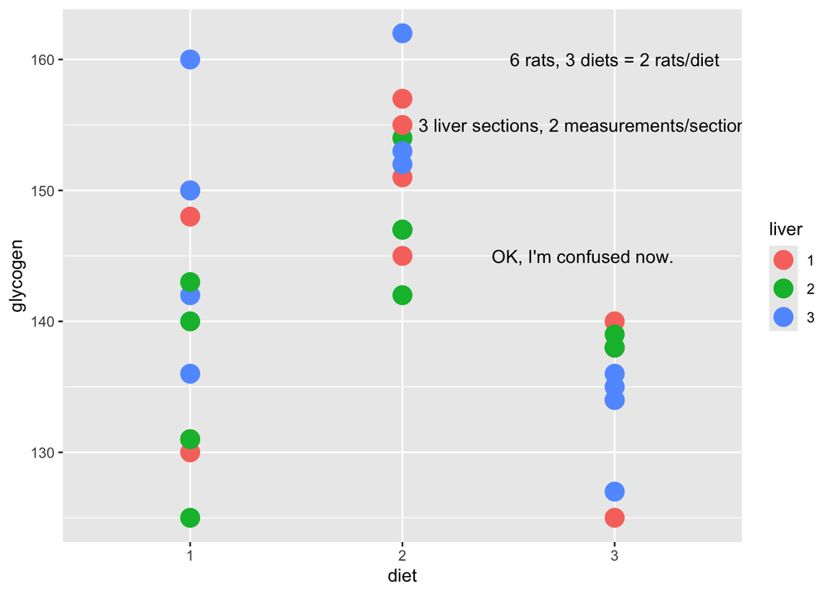

```r
#this visualization is a bit tough because of the way the data are coded (1, 2, 3)
data(rat) #from asbio package
ggplot(rat, aes(diet, glycogen, colour = liver)) +
  geom_point(size=5) +
  annotate("text", x = 3, y = 160, label = "6 rats, 3 diets = 2 rats/diet") +
  annotate("text", x = 2.85, y = 155, label = "3 liver sections, 2 measurements/section") +
  annotate("text", x = 2.85, y = 145, label = "OK, I'm confused now.")
```

As an exercise, make a schematic of what you expect this design to look like.

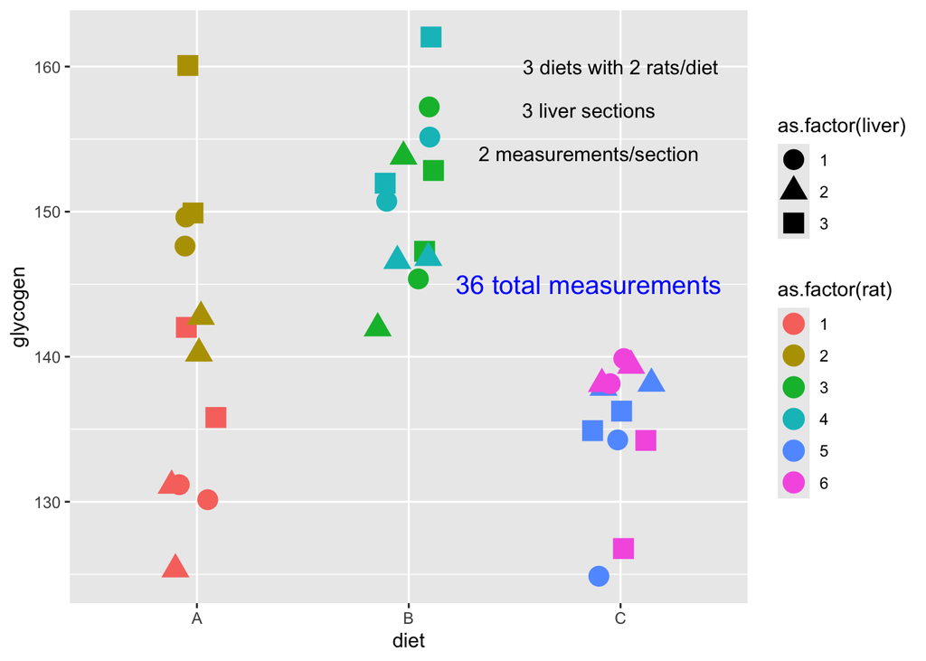

```r
rat_recoded <- read.csv("../data/rat_recoded.csv")
ggplot(rat_recoded, aes(diet, glycogen, colour = as.factor(rat), shape=as.factor(liver))) +
  geom_jitter(width =0.15, size=5) +
  annotate("text", x = 3, y = 160, label = "3 diets with 2 rats/diet") +
  annotate("text", x = 2.85, y = 157, label = "3 liver sections") +
  annotate("text", x = 2.85, y = 154, label = "2 measurements/section") +
  annotate("text", x = 2.85, y = 145, label = "36 total measurements", size=5, color="blue")
```

First, **lets do it the wrong way** and show how pseudoreplication can result in incorrect analyses. Of primary interest is the detection of differences in the fixed factor of diet. By treating each measure in each liver preparation in each rat as independent observations, we get a model with inflated degrees of freedom.

```r
anova(lm(glycogen ~ diet, data = rat))
```

```
## Analysis of Variance Table
##
## Response: glycogen
##           Df Sum Sq Mean Sq F value    Pr(>F)
## diet       2 1557.6  778.78  14.498 3.031e-05 ***
## Residuals 33 1772.7   53.72
## ---
## Signif. codes:  0 '***' 0.001 '**' 0.01 '*' 0.05 '.' 0.1 ' ' 1
```

The analysis tells us that df error = 33; however, there are only six rats. Thus, df error should be n – a = 6 – 3 = 3. Pseudoreplication has artificially inflated sample sizes, and increased the probability of type I error. Using a mixed-model approach, we can obtain variance components estimates for the model.

```r
rat.1 <- lmer(glycogen ~ diet + (1|diet/rat/liver), data = rat)
rat.1
```

```
## Linear mixed model fit by REML ['lmerModLmerTest']
## Formula: glycogen ~ diet + (1 | diet/rat/liver)
##    Data: rat
## REML criterion at convergence: 219.6213
## Random effects:
##  Groups           Name        Std.Dev.
##  liver:(rat:diet) (Intercept) 3.764
##  rat:diet         (Intercept) 6.006
##  diet             (Intercept) 3.953
##  Residual                     4.601
## Number of obs: 36, groups:  liver:(rat:diet), 18; rat:diet, 6; diet, 3
## Fixed Effects:
## (Intercept)        diet2        diet3
##     140.500       10.500       -5.333
## optimizer (nloptwrap) convergence code: 0 (OK) ; 0 optimizer warnings; 1 lme4 warnings
```

```r
summary(rat.1)
```

```
## Linear mixed model fit by REML. t-tests use Satterthwaite's method [
## lmerModLmerTest]
## Formula: glycogen ~ diet + (1 | diet/rat/liver)
##    Data: rat
##
## REML criterion at convergence: 219.6
##
## Scaled residuals:
##      Min       1Q   Median       3Q      Max
## -1.48212 -0.47264  0.03062  0.42934  1.82935
##
## Random effects:
##  Groups           Name        Variance Std.Dev.
##  liver:(rat:diet) (Intercept) 14.17    3.764
##  rat:diet         (Intercept) 36.07    6.006
##  diet             (Intercept) 15.63    3.953
##  Residual                     21.17    4.601
## Number of obs: 36, groups:  liver:(rat:diet), 18; rat:diet, 6; diet, 3
##
## Fixed effects:
##             Estimate Std. Error      df t value Pr(>|t|)
## (Intercept)  140.500      6.147   8.056  22.857  1.3e-08 ***
## diet2         10.500      8.693   8.056   1.208    0.261
## diet3         -5.333      8.693   8.056  -0.614    0.556
## ---
## Signif. codes:  0 '***' 0.001 '**' 0.01 '*' 0.05 '.' 0.1 ' ' 1
##
## Correlation of Fixed Effects:
##       (Intr) diet2
## diet2 -0.707
## diet3 -0.707  0.500
## optimizer (nloptwrap) convergence code: 0 (OK)
## Model is nearly unidentifiable: large eigenvalue ratio
##  - Rescale variables?
```

Look at how samples are parsed: “Number of obs: 36, groups: liver:(rat:diet), 18; rat:diet, 6; diet, 3”. This makes sense.

```r
anova(rat.1)
```

```
## Type III Analysis of Variance Table with Satterthwaite's method
##      Sum Sq Mean Sq NumDF  DenDF F value Pr(>F)
## diet  72.71  36.355     2 8.0557  1.7176 0.2392
```

Notice this inference (P=0.23) is much different than the linear model that included pseudoreplicates of individuals (P=3.031e-05).

Example of Russian Dolls ‘Nested’ Within One Another; Analogous to Nested Effects in Model Specification

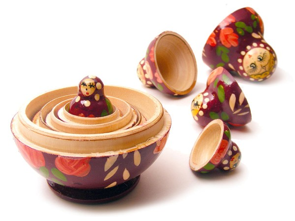

**Nested random effects** are when each member of one group is contained entirely within a single unit of another group. The canonical example is students in classrooms; you may have repeated measures per student, but each student belongs to a single classroom (assuming no reassignments).

**Crossed random effects** are when this nesting is not true. An example would be different seeds and different fields used for planting crops. Seeds of the same type can be planted in different fields, and each field can have multiple seeds in it.

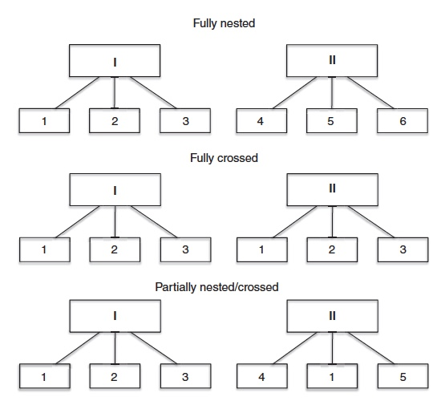